**Instructor copy.** Executed notebook with all results shown, including the "after your attempt" cells. Projector/offline fallback; learners should use the notebook itself.

# f7 · A grain boundary in an open or closed cell

**Learning question:** an invented boundary prefers B atoms. How much B does it take up, where do those atoms come from, and does the answer change when the cell can exchange atoms with a large reservoir or is closed?

Used in: Day 2 D4–D6 and D9, Lessons 11–13, self-study step 04. Work each "your turn" on paper first, then type your value. Labels such as (W4), (D1), (Lesson 5) or Clinic D point to the printed one-day primers (Day 1 and Day 2 worksheets) and the detailed lessons of the classroom course in the repository. Working alone on the website, you only need the step numbers.

**Background.** A grain boundary is the thin region where two crystals of different orientation meet. Atoms there sit in a less regular environment than in the bulk crystal, so some kinds of atoms are more comfortable there. When the boundary takes up more B than the bulk has, B is said to **segregate** to the boundary. Segregation changes boundary properties, and it is one of the uses of CALPHAD-type bulk descriptions beyond phase diagrams.

**The route through the notebook.**

1. Counting: sites, atoms and the boundary **excess** (how much extra B the boundary holds), before any energy appears.
2. **Open cell:** the bulk is connected to a very large reservoir, so its composition stays fixed. A closed formula gives the boundary occupancy.
3. **Closed cell:** the total number of B atoms is fixed, so B that goes to the boundary is missing from the bulk. The answer is found step by step.
4. Practice with fresh numbers, then the course code and pictures for both cells.

Run the setup cell first; it makes the helpers `check` and `confirm` available.

```python
# Setup: run this cell first. Locally it finds the course folder; in Colab it
# downloads the tested course release and the locked package versions.
# In Colab, the first run then restarts the session on purpose and Colab reports
# a crash: that is expected. Run this cell again, then the rest of the notebook.
RELEASE = "main"
import os, pathlib, subprocess, sys, time
ROOT = next((p for p in (pathlib.Path.cwd(), *pathlib.Path.cwd().parents)
             if (p / "pyproject.toml").is_file() and (p / "course").is_dir()), None)
if ROOT is None and "google.colab" in sys.modules:
    ROOT = pathlib.Path("/content/CalphadIntro")
    if not ROOT.is_dir():
        clone = ["git", "clone", "-q", "--depth", "1", "--branch", RELEASE,
                 "https://github.com/ukerzel/CalphadIntro.git", str(ROOT)]
        git = dict(os.environ, GIT_TERMINAL_PROMPT="0")
        if subprocess.run(clone, env=git, capture_output=True).returncode:
            raise SystemExit(f"Could not download course release {RELEASE}: check the internet "
                             "connection and run this cell again.")
    if not (ROOT / ".colab-ready").exists():
        if subprocess.run([sys.executable, "-m", "pip", "install", "-q", "-r",
                           str(ROOT / "notebooks" / "requirements-colab.txt")]).returncode:
            raise SystemExit("Installing the course packages failed; run this cell again.")
        (ROOT / ".colab-ready").touch()
        # Colab has already loaded its own numpy; a fresh session is needed to use the installed versions.
        print("Installed the course's package versions. Colab now restarts this session and"
              " reports a crash; that is expected. When it has reconnected, run this cell again"
              " (it will not install twice), then the rest of the notebook.", flush=True)
        time.sleep(3)
        os.kill(os.getpid(), 9)
if ROOT is None:
    raise SystemExit("Open this notebook from the course folder (poetry run jupyter lab) or in Colab.")
os.chdir(ROOT)
sys.path.insert(0, str(ROOT))
from notebooks.helpers import check, confirm, database, show_versions
show_versions(RELEASE)
```

```
Course release main · Python 3.12.14
  numpy       2.5.3
  scipy       1.18.1
  matplotlib  3.11.2
  xarray      2026.7.0
  pycalphad   0.11.2
```

```
True
```

## 1. Count the boundary before giving it an energy (D4, Lesson 11)

An invented A/B model at T = 1000 K and p = 100000 Pa. The periodic cell has a bulk region and **two equivalent planar boundaries**. Every site holds exactly one A or one B atom.

| Quantity | Value | Unit |
| --- | --- | --- |
| bulk sites $N_b$ | 8000 | sites |
| boundaries $K$ | 2 | — |
| sites per boundary $S$ | 100 | sites |
| area per boundary $A$ | 20 | nm² |
| bulk B fraction $x_b$ | 0…1 | B per bulk site |
| boundary occupancy $\theta$ | 0…1 | B per boundary site |

So the cell has 8000 + 200 = 8200 sites and 40 nm² of boundary. Counts such as $8000\,x_b$ are expected (average) counts and need not be whole numbers.

"Periodic" means the cell repeats itself in every direction, as in a computer simulation; that is why a slab of bulk between two boundaries gives exactly two equivalent boundaries. The occupancy $\theta$ (Greek "theta") is the fraction of boundary sites that hold B; $x_b$ is the same for the bulk sites.

Occupancy $\theta$ is a fraction; it has no area in it. The **equal-site excess** compares the cell with bulk material of fraction $x_b$ filling the same 8200 sites:

$$\Gamma_B=\frac{8000x_b+200\theta-8200x_b}{40\ \mathrm{nm^2}} =\frac{S(\theta-x_b)}{A}=5(\theta-x_b)\ \mathrm{atom/nm^2}.$$

For mol/m²: $1\ \mathrm{nm^2}=10^{-18}\ \mathrm{m^2}$ and one mole is $N_{\rm Av}=6.02214076\times10^{23}$ atoms.

Reading the formula term by term: the numerator is (B atoms actually in the cell) minus (B atoms the same 8200 sites would hold if they all had the bulk fraction). That difference is the extra B that exists *because* of the boundaries. Dividing by the boundary area makes it a property of the boundary per unit area, so it does not depend on how large the cell is. The simplification to $5(\theta-x_b)$ uses $200=2\cdot100$ boundary sites and $40=2\cdot20$ nm²; the 5 is the site density of a boundary, 100 sites per 20 nm².

The code turns this into two small functions. `K, S = 2, 100` assigns two names in one line. Python writes $6.02214076\times10^{23}$ as `6.02214076e23`.

```python
N_BULK = 8000          # bulk sites
K, S = 2, 100          # boundaries; sites per boundary
AREA_NM2 = 20.0        # nm² per boundary
N_AV = 6.02214076e23   # atoms per mol
N_SITES = N_BULK + K * S        # all cell sites
AREA_TOTAL_NM2 = K * AREA_NM2   # nm² of boundary in the cell

def excess_atoms_per_nm2(theta, x_b):
    cell_B = N_BULK * x_b + K * S * theta   # expected B atoms in the cell
    reference_B = N_SITES * x_b             # same sites, all at bulk fraction
    return (cell_B - reference_B) / AREA_TOTAL_NM2   # extra B per nm² of boundary

def atoms_per_nm2_to_mol_per_m2(value):
    return value * 1e18 / N_AV   # 1 m² = 1e18 nm²; N_AV atoms per mol

# Lesson 11 worked inventory: supplied trial occupancies, not an equilibrium.
x_b, theta = 0.10, 0.25
print(f"bulk B = {N_BULK * x_b:.0f}, boundary B = {K * S * theta:.0f}, "
      f"reference B = {N_SITES * x_b:.0f}")
gamma = excess_atoms_per_nm2(theta, x_b)   # atom/nm²
print(f"excess = {gamma:.2f} atom/nm² (site-density route: {S / AREA_NM2 * (theta - x_b):.2f})")
print(f"       = {atoms_per_nm2_to_mol_per_m2(gamma):.4e} mol/m²")   # .4e: scientific notation, 4 decimals
```

```
bulk B = 800, boundary B = 50, reference B = 820
excess = 0.75 atom/nm² (site-density route: 0.75)
       = 1.2454e-06 mol/m²
```

The printout follows the formula: 800 B in the bulk, 50 on the boundaries, 820 in the reference, so 30 extra B over 40 nm², and the short route $5(\theta-x_b)$ gives the same number. In mol/m² the excess is a very small number, because one mole is about $6\times10^{23}$ atoms.

### Your turn

The worksheet trial is $x_b=0.10$, $\theta=0.15$: 800 B in bulk, 30 B on both boundaries, an excess of ten B over 40 nm², so 0.25 atom/nm² (not 30/20).

1. Total A atoms in the cell for this trial (check that A + B = 8200).
2. The excess when $\theta=x_b$.
3. The excess at $\theta=0.08$, $x_b=0.10$. Does a negative excess mean a negative number of B atoms?
4. Units drill: convert 0.25 atom/nm² to mol/m².

Every site holds exactly one atom, so on any group of sites the number of A atoms is the number of sites minus the number of B atoms. You may call the two functions above, e.g. `excess_atoms_per_nm2(0.08, 0.10)`, to check your hand result.

```python
total_A_trial = None       # A atoms in the whole cell
excess_theta_eq_x = None   # atom/nm²
excess_theta_008 = None    # atom/nm²
excess_025_mol_m2 = None   # mol/m²
check(total_A_trial, "f7_d4_total_A")
check(excess_theta_eq_x, "f7_d4_excess_equal")
check(excess_theta_008, "f7_d4_excess_008")
check(excess_025_mol_m2, "f7_d4_mol_m2_025")
```

```
f7_d4_total_A: not attempted yet. Replace None with your value and run the cell again.
f7_d4_excess_equal: not attempted yet. Replace None with your value and run the cell again.
f7_d4_excess_008: not attempted yet. Replace None with your value and run the cell again.
f7_d4_mol_m2_025: not attempted yet. Replace None with your value and run the cell again.
```

Counting is done; now the boundary gets an energy, which decides how much B it actually takes up. The first case is the simpler one: the bulk is so large that the boundary cannot change its composition.

## 2. Open cell: a large reservoir sets the bulk (D5, Lesson 12)

A very large ALPHA bulk reservoir fixes $x_b$ and both chemical potentials $\mu_A$, $\mu_B$. When a B arrives at a boundary site it replaces an A, which goes back to the reservoir; the cell alone does not keep a fixed B count.

The bulk Gibbs energy is the ideal ALPHA curve from Day 2 (J/mol of sites, $RT = 8.3145\times1000 = 8314.5$ J/mol):

$$g_b(x)=-9000+12000\,x+RT\,[x\ln x+(1-x)\ln(1-x)].$$

The invented boundary-site function adds a B preference $\delta$: $g_s(\theta)=g_b(\theta)+\delta\theta$ with $\delta=-5000$ J/mol of boundary sites. The open boundary minimises the grand potential per mole of boundary sites, subtracting **both** reservoirs:

$$\phi(\theta)=g_s(\theta)-(1-\theta)\mu_A-\theta\mu_B .$$

**What the symbols mean.** $g_b(x)$ is the ALPHA curve of f3–f5 at 1000 K: $-9000+12000\,x$ are the weighted pure-element energies ($(1-x)(-9000)+x(3000)$), and the $RT[\dots]$ term is the ideal mixing. The **chemical potential** $\mu_B$ is the Gibbs energy change when one mole of B is added to the reservoir (in J/mol); likewise $\mu_A$. For this curve they are

$$\mu_A=-9000+RT\ln(1-x_b),\qquad \mu_B=-9000+12000+RT\ln x_b ,$$

the two ends (at x = 0 and x = 1) of the tangent line to $g_b$ at $x_b$, as in f3.

The sign of $\delta$: a **negative** $\delta$ lowers the boundary energy more the more B it holds, so the boundary prefers B. $\delta=0$ would make a boundary site exactly like a bulk site.

**Why $\phi$ and not $g_s$.** The boundary does not create its atoms; it takes them from the reservoir. Filling the boundary sites with $(1-\theta)$ mol A and $\theta$ mol B removes atoms whose Gibbs energy in the reservoir is $(1-\theta)\mu_A+\theta\mu_B$. $\phi$ is the energy of the boundary sites minus what those atoms would have had in the reservoir, so it is the net change for the whole system. With the reservoir fixed, the stable $\theta$ is the one with the lowest $\phi$.

**Where the odds formula comes from.** At the minimum, moving one more B onto a boundary site (and one A off it) gains nothing against the reservoir: $d\phi/d\theta = g_s'(\theta)-(\mu_B-\mu_A)=0$. With $g_s'(\theta)=12000+RT\ln\frac{\theta}{1-\theta}+\delta$ and $\mu_B-\mu_A=g_b'(x_b)=12000+RT\ln\frac{x_b}{1-x_b}$, the 12000 cancels:

$$\frac{\theta}{1-\theta}=\frac{x_b}{1-x_b}\,\exp(-\delta/RT), \qquad \exp(5000/8314.5)=1.82459687 .$$

If the odds are $r$, then $\theta=r/(1+r)$.

The steps in between: the derivative of the mixing term is $\frac{d}{dx}[x\ln x+(1-x)\ln(1-x)]=\ln x-\ln(1-x)=\ln\frac{x}{1-x}$. Setting the two derivatives equal and cancelling 12000 leaves $RT\ln\frac{\theta}{1-\theta}+\delta=RT\ln\frac{x_b}{1-x_b}$; divide by RT and take the exponential of both sides. The ratio $\theta/(1-\theta)$ is called the **odds** (B against A on a site). Solving $\theta/(1-\theta)=r$ for $\theta$ gives $\theta=r(1-\theta)$, so $\theta=r/(1+r)$.

In the code, `np.log` is the natural logarithm ln and `np.exp` the exponential. A function argument written `delta=DELTA` has a default value: `phi(0.15, 0.10)` uses δ = −5000 J/mol, and `phi(0.15, 0.10, delta=0.0)` overrides it.

```python
import numpy as np

RT = 8.3145 * 1000.0   # J/mol at T = 1000 K
DELTA = -5000.0        # J/mol boundary sites

def g_bulk(x):
    return -9000.0 + 12000.0 * x + RT * (x * np.log(x) + (1 - x) * np.log(1 - x))   # J/mol sites, 0 < x < 1

def mu_A(x_b):
    return -9000.0 + RT * np.log(1 - x_b)             # J/mol

def mu_B(x_b):
    return -9000.0 + 12000.0 + RT * np.log(x_b)       # J/mol

def g_site(theta, delta=DELTA):
    return g_bulk(theta) + delta * theta              # J/mol boundary sites

def phi(theta, x_b, delta=DELTA):
    # grand potential: boundary energy minus the reservoir energy of the same atoms, J/mol boundary sites
    return g_site(theta, delta) - (1 - theta) * mu_A(x_b) - theta * mu_B(x_b)

def theta_open(x_b, delta=DELTA):
    odds = x_b / (1 - x_b) * np.exp(-delta / RT)   # bulk odds times the preference factor
    return odds / (1 + odds)                       # from odds r to occupancy θ = r/(1 + r)

print(f"factor exp(-δ/RT) = {np.exp(-DELTA / RT):.8f}")
print(f"reservoir at x_b = 0.10: μ_A = {mu_A(0.10):.2f}, μ_B = {mu_B(0.10):.2f}, "
      f"μ_B − μ_A = {mu_B(0.10) - mu_A(0.10):.2f} J/mol")
for trial in (0.10, 0.15, 0.25):   # Lesson 12 trials: compare, do not yet minimise
    print(f"  trial θ = {trial:.2f}: φ = {phi(trial, 0.10):8.2f} J/mol boundary sites")
```

```
factor exp(-δ/RT) = 1.82459687
reservoir at x_b = 0.10: μ_A = -9876.02, μ_B = -16144.84, μ_B − μ_A = -6268.82 J/mol
  trial θ = 0.10: φ =  -500.00 J/mol boundary sites
  trial θ = 0.15: φ =  -648.27 J/mol boundary sites
  trial θ = 0.25: φ =  -482.31 J/mol boundary sites
```

Of these three trials 0.15 is lowest, but three trials do not locate the minimum. φ is in J/mol of **boundary sites** and depends on the chosen reference; it is not an absolute grain-boundary free energy.

### Your turn

At $x_b=0.10$ and $\delta=-5000$ J/mol: the odds, the occupancy, the expected number of B atoms on both boundaries, and the excess in both units. Then set $\delta=0$: what is $\theta$? Why is $\theta$ above $x_b$ for $\delta<0$?

Also reject, in words: "The boundary has 0.16856 mol B, and $\phi$ is its absolute grain-boundary free energy." (Two errors.)

Work from the odds formula with the printed factor. `theta_open(x_b)` and `theta_open(x_b, delta=0.0)` let you check your hand values; the functions of section 1 convert an occupancy into an excess.

```python
odds_open = None           # dimensionless
theta_open_010 = None      # B per boundary site
boundary_B_open = None     # expected B atoms on both boundaries
excess_open = None         # atom/nm²
excess_open_mol_m2 = None  # mol/m²
theta_no_preference = None # B per boundary site, δ = 0
check(odds_open, "f7_d5_odds")
check(theta_open_010, "f7_d5_theta")
check(boundary_B_open, "f7_d5_boundary_B")
check(excess_open, "f7_d5_excess")
check(excess_open_mol_m2, "f7_d5_mol_m2")
check(theta_no_preference, "f7_d5_theta_delta0")
```

```
f7_d5_odds: not attempted yet. Replace None with your value and run the cell again.
f7_d5_theta: not attempted yet. Replace None with your value and run the cell again.
f7_d5_boundary_B: not attempted yet. Replace None with your value and run the cell again.
f7_d5_excess: not attempted yet. Replace None with your value and run the cell again.
f7_d5_mol_m2: not attempted yet. Replace None with your value and run the cell again.
f7_d5_theta_delta0: not attempted yet. Replace None with your value and run the cell again.
```

In the open cell the reservoir supplied every extra B atom without noticing. A real grain usually has no such reservoir: whatever goes to the boundary must come out of the bulk next to it.

## 3. Closed cell: a fixed inventory (D6, Lesson 13)

Now no atoms enter or leave the 8200-site cell. Start with bulk $x_0=0.10$ and both boundaries at $\theta_0=0.25$. Total B is $8000x_0+200\theta_0$ and total A is $8200-B_{\rm tot}$. B that moves to the boundaries must come from the bulk:

$$x_b(\theta)=\frac{B_{\rm tot}-200\theta}{8000}.$$

The closed cell minimises its **total** Gibbs energy, here per mole of all 8200 cell sites (no reservoir subtraction):

$$\bar g(\theta)=\frac{8000\,g_b[x_b(\theta)]+200\,g_s(\theta)}{8200}.$$

Differentiating with $dx_b/d\theta=-200/8000$ gives the same exchange condition as the open cell, $g_s'(\theta)=g_b'(x_b)$, but now $x_b$ moves with $\theta$. A hand method: put the current $x_b$ into the odds formula to get $\theta$, update $x_b$ from the inventory, and repeat.

The derivative written out (chain rule for the bulk term):

$$\frac{d\bar g}{d\theta}=\frac{8000\,g_b'(x_b)\left(-\frac{200}{8000}\right)+200\,g_s'(\theta)}{8200} =\frac{200}{8200}\,\bigl[g_s'(\theta)-g_b'(x_b)\bigr]=0 .$$

The bar in $\bar g$ marks an average over all cell sites. Here there is nothing to subtract: no atoms leave the cell, so its total Gibbs energy is the quantity to minimise. The two unknowns $\theta$ and $x_b$ are tied together by the B balance, so one equation cannot be solved for $\theta$ alone in closed form. The hand method solves it by repetition: every round moves a little B between bulk and boundary, and because the boundaries have only 200 sites against 8000 in the bulk, $x_b$ changes only slightly from round to round, so the rounds settle quickly.

In the code, `hand_round` performs one round and returns two values, `(θ, new x_b)`.

```python
def x_bulk_closed(theta, B_total):
    return (B_total - K * S * theta) / N_BULK   # B per bulk site

def g_bar_closed(theta, B_total, delta=DELTA):
    x_b = x_bulk_closed(theta, B_total)
    return (N_BULK * g_bulk(x_b) + K * S * g_site(theta, delta)) / N_SITES   # J/mol all cell sites

def hand_round(x_b, B_total, delta=DELTA):
    theta = theta_open(x_b, delta)              # odds formula at the current bulk
    return theta, x_bulk_closed(theta, B_total) # new occupancy, updated bulk

B_total = N_BULK * 0.10 + K * S * 0.25   # B atoms in the cell, fixed from now on
for trial in (0.10, 0.15, 0.20, 0.25):   # Lesson 13 trials of the same closed cell
    print(f"  trial θ = {trial:.2f}: x_b = {x_bulk_closed(trial, B_total):.5f}, "
          f"ḡ = {g_bar_closed(trial, B_total):.4f} J/mol all cell sites")
```

```
  trial θ = 0.10: x_b = 0.10375, ḡ = -10537.4054 J/mol all cell sites
  trial θ = 0.15: x_b = 0.10250, ḡ = -10541.3690 J/mol all cell sites
  trial θ = 0.20: x_b = 0.10125, ḡ = -10541.1526 J/mol all cell sites
  trial θ = 0.25: x_b = 0.10000, ḡ = -10537.6008 J/mol all cell sites
```

These ḡ values compare states of the **same** closed cell. They cannot be ranked against the open φ values: different energies on different bases.

Note how $x_b$ in the printout falls as the trial $\theta$ rises: B on the boundary is B missing from the bulk.

### Your turn

1. Total B and total A of the cell.
2. Trial $\theta=0.35$: boundary B, bulk B and $x_b$. How many B would the cell hold if you kept $x_b=0.10$ instead?
3. Hand iteration, round 1: start with $x_b=x_0=0.10$, get $\theta$ from the odds formula, then the updated $x_b$.
4. Keep going (use `hand_round` in a loop) until θ stops changing in the fifth decimal. Give the settled $\theta$, $x_b$ and boundary B count.

A loop for question 4 can look like this (type it into a new cell):

```
x_b = 0.10
for k in range(8):
    theta, x_b = hand_round(x_b, B_total)
    print(k + 1, round(theta, 6), round(x_b, 6))
```

`range(8)` repeats the indented lines 8 times; each round starts from the `x_b` that the previous round returned.

```python
closed_total_B = None        # B atoms in the cell
closed_total_A = None        # A atoms in the cell
boundary_B_035 = None        # B atoms on both boundaries at θ = 0.35
bulk_B_035 = None            # B atoms in the bulk at θ = 0.35
x_b_035 = None               # B per bulk site at θ = 0.35
wrong_B_035 = None           # B atoms if x_b stayed 0.10
theta_round1 = None          # B per boundary site after round 1
x_b_round1 = None            # B per bulk site after round 1
theta_closed = None          # settled occupancy
x_b_closed = None            # settled bulk fraction
boundary_B_closed = None     # settled B atoms on both boundaries
check(closed_total_B, "f7_d6_total_B")
check(closed_total_A, "f7_d6_total_A")
check(boundary_B_035, "f7_d6_boundary_B_035")
check(bulk_B_035, "f7_d6_bulk_B_035")
check(x_b_035, "f7_d6_x_b_035")
check(wrong_B_035, "f7_d6_wrong_B_035")
check(theta_round1, "f7_d6_theta_round1")
check(x_b_round1, "f7_d6_x_b_round1")
check(theta_closed, "f7_d6_theta_final")
check(x_b_closed, "f7_d6_x_b_final")
check(boundary_B_closed, "f7_d6_boundary_B_final")
```

```
f7_d6_total_B: not attempted yet. Replace None with your value and run the cell again.
f7_d6_total_A: not attempted yet. Replace None with your value and run the cell again.
f7_d6_boundary_B_035: not attempted yet. Replace None with your value and run the cell again.
f7_d6_bulk_B_035: not attempted yet. Replace None with your value and run the cell again.
f7_d6_x_b_035: not attempted yet. Replace None with your value and run the cell again.
f7_d6_wrong_B_035: not attempted yet. Replace None with your value and run the cell again.
f7_d6_theta_round1: not attempted yet. Replace None with your value and run the cell again.
f7_d6_x_b_round1: not attempted yet. Replace None with your value and run the cell again.
f7_d6_theta_final: not attempted yet. Replace None with your value and run the cell again.
f7_d6_x_b_final: not attempted yet. Replace None with your value and run the cell again.
f7_d6_boundary_B_final: not attempted yet. Replace None with your value and run the cell again.
```

### Dive deeper (optimisation view): open versus closed is a Lagrangian relaxation

Write the closed cell as an optimisation problem with an explicit constraint. Count the sites as moles (8000 mol of bulk sites, 200 mol of boundary sites); the unknowns are the B amounts in the bulk, $n_b$, and on the boundaries, $n_s$. Minimise the total $G=8000\,g_b(n_b/8000)+200\,g_s(n_s/200)$ subject to the B balance $n_b+n_s=B_{\rm tot}$. With a multiplier $\lambda$ for that one constraint, both parts must satisfy the same condition:

$$g_b'(x_b)=\lambda,\qquad g_s'(\theta)=\lambda .$$

For a *fixed* $\lambda$ each part can be solved alone, and that is exactly the open cell: a reservoir that buys and sells B at the fixed exchange price $\lambda=\mu_B-\mu_A$. The open cell is the closed cell with the B balance relaxed and priced. The closed cell is then a one-unknown problem: find the price $\lambda$ at which bulk and boundary together hold exactly $B_{\rm tot}$. Both conditions have closed forms ($x_b$ and $\theta$ are logistic functions of $\lambda$), so one bracketed root search finds it.

```python
from scipy.optimize import brentq

logistic = lambda u: 1 / (1 + np.exp(-u))
x_of = lambda lam: logistic((lam - 12000.0) / RT)            # g_b'(x_b) = lam, solved for x_b
theta_of = lambda lam: logistic((lam - 12000.0 - DELTA) / RT)   # g_s'(θ) = lam, solved for θ
lam = brentq(lambda l: N_BULK * x_of(l) + K * S * theta_of(l) - B_total, -40000.0, 20000.0, xtol=1e-12)
x_b_lam, theta_lam = x_of(lam), theta_of(lam)
print(f"multiplier λ = {lam:.3f} J/mol;  x_b = {x_b_lam:.6f},  θ = {theta_lam:.6f}")
print(f"μ_B − μ_A at that x_b = {mu_B(x_b_lam) - mu_A(x_b_lam):.3f} J/mol")
assert abs(lam - (mu_B(x_b_lam) - mu_A(x_b_lam))) < 1e-6, "the multiplier should be the exchange price"
```

```
multiplier λ = -6089.326 J/mol;  x_b = 0.101960,  θ = 0.171608
μ_B − μ_A at that x_b = -6089.326 J/mol
```

Three checks. The hand iteration of section 3 settles at the same θ. The open cell, with a reservoir at the closed cell's final $x_b$, selects the same θ. And the multiplier is a price in the everyday sense: adding a little B to the closed cell changes its lowest total G by $\lambda$ per mole of B (a central difference, with the cell's G found by a one-dimensional search).

```python
from scipy.optimize import minimize_scalar

x_hand = 0.10
for _ in range(30):                                          # the hand iteration, run to the end
    theta_hand, x_hand = hand_round(x_hand, B_total)
print(f"hand iteration: θ = {theta_hand:.6f};  open cell at x_b = {x_b_lam:.6f}: θ = {theta_open(x_b_lam):.6f}")
assert abs(theta_hand - theta_lam) < 1e-9 and abs(theta_open(x_b_lam) - theta_lam) < 1e-12, "the three routes should agree"

def G_cell(B):                                               # lowest total G of a closed cell holding B
    f = lambda t: N_BULK * g_bulk((B - K * S * t) / N_BULK) + K * S * g_site(t)
    return minimize_scalar(f, bounds=(1e-9, 1 - 1e-9), method="bounded", options={"xatol": 1e-12}).fun
h = 0.01
print(f"dG/dB_tot ≈ {(G_cell(B_total + h) - G_cell(B_total - h)) / (2 * h):.2f} J/mol B, against λ = {lam:.2f}")
```

```
hand iteration: θ = 0.171608;  open cell at x_b = 0.101960: θ = 0.171608
dG/dB_tot ≈ -6089.33 J/mol B, against λ = -6089.33
```

The hand iteration of section 3 is price coordination: guess the price (the bulk's μ_B − μ_A), let the boundary answer at that price, update the price from the inventory, repeat. It converges quickly here because the 200 boundary sites barely move the 8000-site bulk; that is a property of this cell, not a guarantee for every closed problem. The advanced steps read every equilibrium calculation this way: constraints, their prices, and what a relaxed problem can and cannot promise.

## 4. A fresh card (D9) and more practice (self-study step 04)

Same invented parameters, factor 1.82459687. These are two different experiments, even though both start with the number 0.20.

- **Open**: reservoir $x_b=0.20$. Find the odds, $\theta$, the excess in atom/nm², and the excess B count across the 40 nm² of both boundaries.
- **Closed**: a new 8200-site cell with $x_0=0.20$, $\theta_0=0.20$ and trial $\theta=0.40$. Find total B, boundary B, bulk B and $x_b$; how many B would "keep $x_b=0.20$ because the open reservoir did" give?
- **Baseline**: a different boundary state could carry an extra baseline $\eta=2000$ J/mol of boundary sites. How much does that add per mole of all 8200 cell sites?

Then write two sentences about a colleague who calls a model energy crossing a measured Ni–Cu boundary transition that strengthens the alloy: one statement this invented model does support, and one exact reason the claim does not follow.

A **baseline** $\eta$ (Greek "eta") is a constant added to the boundary-site energy, $g_s(\theta)+\eta$, the same for every occupancy. For the baseline question, look again at how $\bar g$ in section 3 weights the boundary sites against all cell sites.

```python
odds_020 = None            # dimensionless
theta_020 = None           # B per boundary site
excess_020 = None          # atom/nm²
excess_count_020 = None    # excess B atoms over both boundaries
card_total_B = None        # B atoms in the closed cell
card_boundary_B = None     # B atoms on both boundaries at θ = 0.40
card_bulk_B = None         # B atoms in the bulk at θ = 0.40
card_x_b = None            # B per bulk site at θ = 0.40
card_wrong_B = None        # B atoms if x_b stayed 0.20
baseline_per_cell_site = None   # J/mol all cell sites
check(odds_020, "f7_d9_odds")
check(theta_020, "f7_d9_theta")
check(excess_020, "f7_d9_excess")
check(excess_count_020, "f7_d9_excess_count")
check(card_total_B, "f7_d9_total_B")
check(card_boundary_B, "f7_d9_boundary_B")
check(card_bulk_B, "f7_d9_bulk_B")
check(card_x_b, "f7_d9_x_b")
check(card_wrong_B, "f7_d9_wrong_B")
check(baseline_per_cell_site, "f7_baseline_eta")
```

```
f7_d9_odds: not attempted yet. Replace None with your value and run the cell again.
f7_d9_theta: not attempted yet. Replace None with your value and run the cell again.
f7_d9_excess: not attempted yet. Replace None with your value and run the cell again.
f7_d9_excess_count: not attempted yet. Replace None with your value and run the cell again.
f7_d9_total_B: not attempted yet. Replace None with your value and run the cell again.
f7_d9_boundary_B: not attempted yet. Replace None with your value and run the cell again.
f7_d9_bulk_B: not attempted yet. Replace None with your value and run the cell again.
f7_d9_x_b: not attempted yet. Replace None with your value and run the cell again.
f7_d9_wrong_B: not attempted yet. Replace None with your value and run the cell again.
f7_baseline_eta: not attempted yet. Replace None with your value and run the cell again.
```

## 5. After your attempt: the course code and the pictures

The course modules `boundary_one_state` and `boundary_closed` solve the same model independently: a bounded minimiser on the full energy, checked against the odds formula (open) or the exchange root (closed).

A **bounded minimiser** (here `scipy.optimize.minimize_scalar` with `method="bounded"`) searches for the lowest value of a function of one variable between two limits, here $0\le\theta\le1$, without using any formula for the answer. That makes it an independent check on the odds formula.

**The first cell (open cell)** confirms your D4 and D5 values and then draws two panels.

- **Left, the tangent picture.** The dotted line is the tangent to the bulk curve $g_b$ at the reservoir composition $x_b=0.10$; its height at any x is $(1-x)\mu_A+x\mu_B$. The boundary curve $g_s$ (dashed) lies below $g_b$ because of $\delta$. The selected $\theta$ is where a line **parallel** to the reservoir tangent just touches $g_s$: there the slope of $g_s$ equals $\mu_B-\mu_A$, which is the exchange condition. The arrow is $\phi$, the vertical distance between $g_s$ and the reservoir tangent at $\theta$.
- **Right:** $\phi(\theta)$ itself, with the three Lesson 12 trials and the minimum.

`lambda z: ...` defines a small unnamed function in one line; here it is the reservoir tangent line.

```
D4: A = 7370; excess at θ = 0.08: -0.10 atom/nm²; 0.25 atom/nm² = 4.15135e-07 mol/m²
✓ A + B for the D4 trial reproduces the lesson value.
✓ Excess at θ = 0.08 reproduces the lesson value.
✓ 0.25 atom/nm² in mol/m² reproduces the lesson value.

Open cell at x_b = 0.10: {'theta': 0.16856025544018116, 'theta_analytic': 0.16856026094779272, 'phi_J_per_mol_sites': -658.8072222537612, 'gamma_B_mol_per_m2': 5.692349130691953e-07}
odds = 0.20273299, θ = 0.16856026, boundary B = 33.7121, excess = 0.3428013 atom/nm²
✓ Open odds reproduces the lesson value.
✓ Open occupancy (minimiser) reproduces the lesson value.
✓ Open occupancy (odds formula) reproduces the lesson value.
✓ Open excess in atom/nm² reproduces the lesson value.
✓ Open excess in mol/m² reproduces the lesson value.
✓ φ at the open minimum reproduces the lesson value.
✓ θ at zero preference reproduces the lesson value.
```

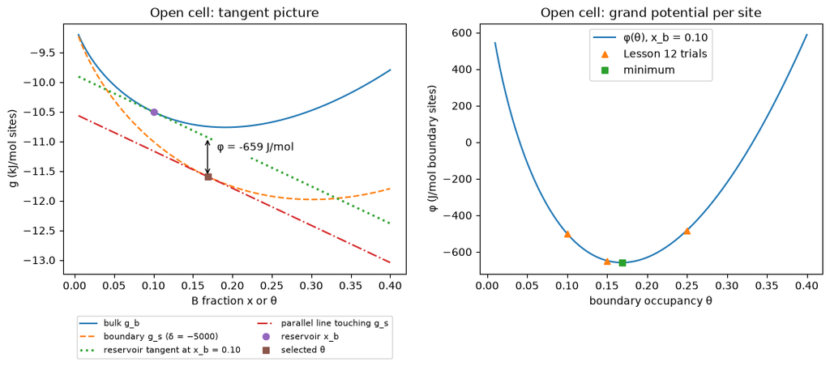

```
 θ      φ (J/mol boundary sites)
 0.10000    -500.00
 0.15000    -648.27
 0.16856    -658.81
 0.25000    -482.31
```

```python
#@title After your attempt: open cell, numbers and the tangent picture
from course.foundations import boundary_one_state as one_state
import matplotlib.pyplot as plt

# D4: A atoms = 8000(1 − 0.10) in the bulk + 200(1 − 0.15) on the boundaries.
print("D4:", f"A = {8000 * 0.90 + 200 * 0.85:.0f};",
      f"excess at θ = 0.08: {excess_atoms_per_nm2(0.08, 0.10):.2f} atom/nm²;",
      f"0.25 atom/nm² = {atoms_per_nm2_to_mol_per_m2(0.25):.5e} mol/m²")
confirm(8000 * 0.90 + 200 * 0.85 + 830, 8200, "A + B for the D4 trial", tol=1e-9)
confirm(excess_atoms_per_nm2(0.08, 0.10), -0.10, "Excess at θ = 0.08", tol=1e-9)
confirm(atoms_per_nm2_to_mol_per_m2(0.25), 4.15135e-7, "0.25 atom/nm² in mol/m²", tol=1e-11)

# D5: the course minimiser against the odds formula.
result = one_state.open_equilibrium(0.10, DELTA)   # dict with θ (minimiser), θ (formula), φ and the excess in mol/m²
print("\nOpen cell at x_b = 0.10:", {k: result[k] for k in ("theta", "theta_analytic", "phi_J_per_mol_sites", "gamma_B_mol_per_m2")})
odds = 0.10 / 0.90 * 1.82459687   # bulk odds times the preference factor
print(f"odds = {odds:.8f}, θ = {odds / (1 + odds):.8f}, boundary B = {200 * odds / (1 + odds):.4f}, "
      f"excess = {5 * (odds / (1 + odds) - 0.10):.7f} atom/nm²")
confirm(odds, 0.20273299, "Open odds", tol=1e-8)
confirm(result["theta"], 0.16856026, "Open occupancy (minimiser)", tol=1e-6)
confirm(theta_open(0.10), 0.16856026, "Open occupancy (odds formula)", tol=1e-8)
confirm(5 * (theta_open(0.10) - 0.10), 0.3428013, "Open excess in atom/nm²", tol=1e-7)
confirm(result["gamma_B_mol_per_m2"], 5.69235e-7, "Open excess in mol/m²", tol=1e-11)
confirm(result["phi_J_per_mol_sites"], -658.80722, "φ at the open minimum", tol=1e-4)
confirm(theta_open(0.10, delta=0.0), 0.10, "θ at zero preference", tol=1e-12)

# Tangent picture at x_b = 0.10: the boundary settles where a line parallel to
# the reservoir tangent touches g_s; φ is the vertical gap between the two lines.
x = np.linspace(0.005, 0.40, 200)   # composition grid; avoids x = 0, where ln x is undefined
xb, th = 0.10, theta_open(0.10)
reservoir_line = lambda z: (1 - z) * mu_A(xb) + z * mu_B(xb)   # tangent to g_b at x_b, J/mol
slope = mu_B(xb) - mu_A(xb)                                    # slope of that tangent, J/mol
fig, (left, right) = plt.subplots(1, 2, figsize=(11, 5))
left.plot(x, g_bulk(x) / 1000, "-", label="bulk g_b")
left.plot(x, g_site(x) / 1000, "--", label="boundary g_s (δ = −5000)")
left.plot(x, reservoir_line(x) / 1000, ":", lw=2, label="reservoir tangent at x_b = 0.10")
left.plot(x, (g_site(th) + slope * (x - th)) / 1000, "-.", label="parallel line touching g_s")   # same slope, through (θ, g_s(θ))
left.plot([xb], [g_bulk(xb) / 1000], "o", label="reservoir x_b")
left.plot([th], [g_site(th) / 1000], "s", label="selected θ")
# Double-headed arrow from the tangent down to g_s at θ: its length is φ.
left.annotate("", xy=(th, g_site(th) / 1000), xytext=(th, reservoir_line(th) / 1000),
              arrowprops=dict(arrowstyle="<->"))
left.text(th + 0.012, (g_site(th) + 2 * reservoir_line(th)) / 3000, f"φ = {phi(th, xb):.0f} J/mol",
          bbox=dict(facecolor="white", edgecolor="none"))   # label placed one third of the way down the arrow
left.set(xlabel="B fraction x or θ", ylabel="g (kJ/mol sites)", title="Open cell: tangent picture")
left.legend(fontsize=8, loc="upper center", bbox_to_anchor=(0.5, -0.15), ncol=2)   # legend below the panel
grid = np.linspace(0.01, 0.40, 200)
right.plot(grid, phi(grid, xb), "-", label="φ(θ), x_b = 0.10")
right.plot([0.10, 0.15, 0.25], [phi(t, xb) for t in (0.10, 0.15, 0.25)], "^", label="Lesson 12 trials")
right.plot([th], [phi(th, xb)], "s", label="minimum")
right.set(xlabel="boundary occupancy θ", ylabel="φ (J/mol boundary sites)", title="Open cell: grand potential per site")
right.legend()
fig.tight_layout()
plt.show()
print(" θ      φ (J/mol boundary sites)")
for t in (0.10, 0.15, round(th, 5), 0.25):
    print(f" {t:.5f}  {phi(t, xb):9.2f}")
```

**The second cell (closed cell)** confirms your D6 values, prints the hand iteration round by round, and compares the open and closed cells.

- `closed.closed_trial(θ, B_tot, δ, 8000)` evaluates one trial occupancy of a closed cell with 8000 bulk sites; `closed.closed_equilibrium(x0, δ, n_bulk)` finds its minimum (starting from $\theta_0=0.25$).
- The loop over 80000 and 800000 bulk sites makes the bulk 10 and 100 times larger. The closed occupancy then moves towards the open result: a very large closed bulk behaves like a reservoir.
- **Left panel:** the selected occupancy against $x_b$ (open) or $x_0$ (closed). The dotted line $\theta=x$ is "no preference"; both curves lie above it because $\delta<0$. The closed cell starts with $\theta_0=0.25$ (dash-dotted line). Where the selected $\theta$ is above 0.25, the boundary has to take extra B out of the finite bulk, which lowers $x_b$, so the closed $\theta$ ends a little below the open one. Where it is below 0.25 (at 0.10), the boundary gives B back to the bulk and the closed $\theta$ ends a little above the open one.
- **Right panel:** $\theta$ after each round of the hand iteration, approaching the closed minimum (dashed), not the open result (dotted).

```
Closed trial θ = 0.35: boundary B = 70, bulk B = 780, x_b = 0.0975
✓ Bulk fraction at θ = 0.35 reproduces the lesson value.
✓ ḡ at θ = 0.10 reproduces the lesson value.
✓ ḡ at θ = 0.10 from the formula above reproduces the lesson value.
✓ ḡ at θ = 0.15 reproduces the lesson value.
✓ ḡ at θ = 0.15 from the formula above reproduces the lesson value.
✓ ḡ at θ = 0.20 reproduces the lesson value.
✓ ḡ at θ = 0.20 from the formula above reproduces the lesson value.
✓ ḡ at θ = 0.25 reproduces the lesson value.
✓ ḡ at θ = 0.25 from the formula above reproduces the lesson value.

round  x_b used    θ           boundary B  bulk B
    1  0.10000000  0.16856026  33.7121     816.2879
    2  0.10203599  0.17172579  34.3452     815.6548
    3  0.10195686  0.17160293  34.3206     815.6794
    4  0.10195993  0.17160770  34.3215     815.6785
    5  0.10195981  0.17160752  34.3215     815.6785
    6  0.10195981  0.17160752  34.3215     815.6785
✓ Round 1 occupancy reproduces the lesson value.
✓ Round 1 bulk fraction reproduces the lesson value.

Closed cell from x0 = 0.10, θ0 = 0.25: {'theta': 0.17160753314081367, 'theta_root': 0.17160752408695693, 'x_bulk': 0.10195981167147966, 'G_molar_J_per_mol_sites': -10541.726792448386}
✓ Closed occupancy (minimiser) reproduces the lesson value.
✓ Closed occupancy (exchange root) reproduces the lesson value.
✓ Closed bulk fraction reproduces the lesson value.
✓ Boundary B at the closed minimum reproduces the lesson value.
✓ B inventory reproduces the lesson value.
✓ Closed occupancy with 80000 bulk sites reproduces the lesson value.
✓ Closed occupancy with 800000 bulk sites reproduces the lesson value.
```

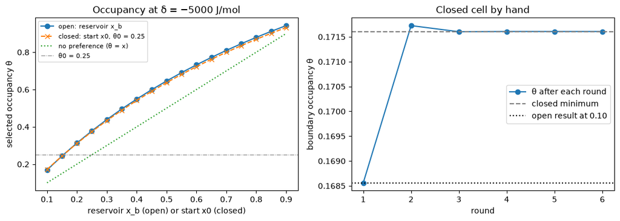

```
 x      θ open      θ closed
 0.10   0.168560   0.171608
 0.15   0.243563   0.243788
 0.20   0.313257   0.311198
 0.25   0.378186   0.374281
 0.30   0.438823   0.433430
 0.35   0.495580   0.488990
 0.40   0.548817   0.541271
 0.45   0.598853   0.590547
 0.50   0.645967   0.637065
 0.55   0.690409   0.681045
 0.60   0.732398   0.722685
 0.65   0.772134   0.762163
 0.70   0.809792   0.799640
 0.75   0.845531   0.835262
 0.80   0.879495   0.869162
 0.85   0.911812   0.901459
 0.90   0.942599   0.932262
```

```python
#@title After your attempt: closed cell, the hand iteration and both cells side by side
from course.foundations import boundary_closed as closed
from course.self_study.boundary_export import hand_iteration

trial = closed.closed_trial(0.35, 850, DELTA, 8000)   # θ = 0.35 in the 850-B cell with 8000 bulk sites
print(f"Closed trial θ = 0.35: boundary B = {200 * 0.35:.0f}, bulk B = {850 - 200 * 0.35:.0f}, x_b = {trial['x_bulk']:.4f}")
confirm(trial["x_bulk"], 0.0975, "Bulk fraction at θ = 0.35", tol=1e-12)
# ḡ at the four Lesson 13 trials, from the course module and from g_bar_closed above.
for t, expected in ((0.10, -10537.4054), (0.15, -10541.3690), (0.20, -10541.1526), (0.25, -10537.6008)):
    confirm(closed.closed_trial(t, 850, DELTA, 8000)["G_molar_J_per_mol_sites"], expected, f"ḡ at θ = {t:.2f}", tol=1e-4)
    confirm(g_bar_closed(t, 850), expected, f"ḡ at θ = {t:.2f} from the formula above", tol=1e-4)

steps = hand_iteration()["steps"]   # list of rounds; each round is a dict with k, x_b_used, theta, boundary_B, bulk_B
print("\nround  x_b used    θ           boundary B  bulk B")
for s in steps:
    print(f"{s['k']:>5}  {s['x_b_used']:.8f}  {s['theta']:.8f}  {s['boundary_B']:.4f}     {s['bulk_B']:.4f}")
confirm(steps[0]["theta"], 0.16856026, "Round 1 occupancy", tol=1e-8)
confirm((850 - steps[0]["boundary_B"]) / 8000, 0.10203599, "Round 1 bulk fraction", tol=1e-8)

final = closed.closed_equilibrium(0.10, DELTA, 8000)   # minimiser and exchange root for x0 = 0.10, θ0 = 0.25
print("\nClosed cell from x0 = 0.10, θ0 = 0.25:", {k: final[k] for k in ("theta", "theta_root", "x_bulk", "G_molar_J_per_mol_sites")})
confirm(final["theta"], 0.17160753, "Closed occupancy (minimiser)", tol=1e-7)
confirm(final["theta_root"], 0.17160752, "Closed occupancy (exchange root)", tol=1e-7)
confirm(final["x_bulk"], 0.10195981, "Closed bulk fraction", tol=1e-7)
confirm(200 * final["theta_root"], 34.3215, "Boundary B at the closed minimum", tol=1e-4)
confirm(200 * final["theta_root"] + 8000 * x_bulk_closed(final["theta_root"], 850), 850, "B inventory", tol=1e-9)
for nb, expected in ((80000, 0.16887598), (800000, 0.16859187)):   # bigger bulk → open result
    confirm(closed.closed_equilibrium(0.10, DELTA, nb)["theta"], expected, f"Closed occupancy with {nb} bulk sites", tol=1e-7)

# Open and closed occupancy for bulk fractions 0.10, 0.15, …, 0.90.
starts = np.round(np.arange(0.10, 0.901, 0.05), 2)   # rounded to 2 decimals to avoid values like 0.15000000000000002
open_theta = [one_state.open_equilibrium(z, DELTA)["theta"] for z in starts]
closed_theta = [closed.closed_equilibrium(z, DELTA, 8000)["theta"] for z in starts]
fig, (left, right) = plt.subplots(1, 2, figsize=(11, 4))
left.plot(starts, open_theta, "o-", label="open: reservoir x_b")
left.plot(starts, closed_theta, "x--", label="closed: start x0, θ0 = 0.25")
left.plot(starts, starts, ":", label="no preference (θ = x)")
left.axhline(0.25, color="grey", lw=0.8, ls="-.", label="θ0 = 0.25")
left.set(xlabel="reservoir x_b (open) or start x0 (closed)", ylabel="selected occupancy θ",
         title="Occupancy at δ = −5000 J/mol")
left.legend(fontsize=8)
rounds = [s["k"] for s in steps]   # round numbers 1, 2, …
right.plot(rounds, [s["theta"] for s in steps], "o-", label="θ after each round")
right.axhline(final["theta_root"], ls="--", color="grey", label="closed minimum")
right.axhline(theta_open(0.10), ls=":", color="black", label="open result at 0.10")
right.set(xlabel="round", ylabel="boundary occupancy θ", title="Closed cell by hand")
right.legend()
fig.tight_layout()
plt.show()
print(" x      θ open      θ closed")
for z, a, b in zip(starts, open_theta, closed_theta):
    print(f" {z:.2f}   {a:.6f}   {b:.6f}")
```

**The third cell** confirms the D9 card. Note in the closed card how much B the "keep $x_b=0.20$" reasoning would need compared with the fixed total: the difference is B that the closed cell does not have. The baseline line shows the weighting $200\,\eta/8200$: only the 200 boundary sites carry $\eta$, but the energy is expressed per mole of all 8200 cell sites.

```python
#@title After your attempt: the D9 card and the step 04 practice
# Open card: reservoir x_b = 0.20.
odds = 0.20 / 0.80 * 1.82459687
print(f"Open x_b = 0.20: odds = {odds:.8f}, θ = {theta_open(0.20):.8f}, "
      f"excess = {5 * (theta_open(0.20) - 0.20):.6f} atom/nm² = {200 * (theta_open(0.20) - 0.20):.4f} B over 40 nm²")
confirm(odds, 0.45614922, "Open odds at 0.20", tol=1e-8)
confirm(one_state.open_equilibrium(0.20, DELTA)["theta"], 0.31325719, "Open occupancy at 0.20 (minimiser)", tol=1e-6)
confirm(5 * (theta_open(0.20) - 0.20), 0.566286, "Open excess at 0.20", tol=1e-6)
confirm(excess_atoms_per_nm2(theta_open(0.20), 0.20) * 40, 22.6514, "Excess B count over 40 nm²", tol=1e-4)

# Closed card: x0 = 0.20, θ0 = 0.20, trial θ = 0.40.
card_B = 8000 * 0.20 + 200 * 0.20   # fixed total B of this cell
card = closed.closed_trial(0.40, card_B, DELTA, 8000)
print(f"Closed x0 = 0.20, θ0 = 0.20: B_tot = {card_B:.0f}; trial θ = 0.40: boundary B = {200 * 0.40:.0f}, "
      f"bulk B = {card_B - 200 * 0.40:.0f}, x_b = {card['x_bulk']:.3f}; keeping x_b = 0.20 would need {8000 * 0.20 + 200 * 0.40:.0f} B")
confirm(card_B, 1640, "Closed total B", tol=1e-9)
confirm(card["x_bulk"], 0.195, "Closed trial bulk fraction", tol=1e-12)
# Baseline: 2000 J/mol on 200 boundary sites, expressed per mole of all 8200 cell sites.
confirm(200 * 2000 / 8200, 48.78049, "Baseline per mole of all cell sites", tol=1e-5)
```

```
Open x_b = 0.20: odds = 0.45614922, θ = 0.31325719, excess = 0.566286 atom/nm² = 22.6514 B over 40 nm²
✓ Open odds at 0.20 reproduces the lesson value.
✓ Open occupancy at 0.20 (minimiser) reproduces the lesson value.
✓ Open excess at 0.20 reproduces the lesson value.
✓ Excess B count over 40 nm² reproduces the lesson value.
Closed x0 = 0.20, θ0 = 0.20: B_tot = 1640; trial θ = 0.40: boundary B = 80, bulk B = 1560, x_b = 0.195; keeping x_b = 0.20 would need 1680 B
✓ Closed total B reproduces the lesson value.
✓ Closed trial bulk fraction reproduces the lesson value.
✓ Baseline per mole of all cell sites reproduces the lesson value.
```

Full worked answers and discussion: Day 2 answers (D4–D6, D9) and Lessons 11, 12 and 13.

## 6. Limits

The boundary is invented: its preference δ, sites and area are chosen numbers, not measured properties of any real grain boundary, and the bulk is the invented ideal ALPHA curve. The excess uses one chosen equal-site reference; a real interface with another site density would need its own definition. One boundary state cannot show a boundary transition. The open and closed cells minimise different energies, so their values are never ranked against each other. Next: f8 · two candidate boundary states.